# Descriptive statistics of iconicity ratings

Bodo Winter

03/09/2021

## Introduction

This script is focused *just* on the norms, without considering any other variables. The `substantive_analysis.Rmd` script is focused on correlating the new norms with other variables to demonstrate construct validity.

## Data and package loading

Load packages:

```r
library(tidyverse, quietly = TRUE)
library(patchwork, quietly = TRUE)
library(qqplotr, quietly = TRUE)
```

For reproducibility:

```r
packageVersion('tidyverse')
```

```
## [1] '1.3.2'
```

```r
packageVersion('patchwork')
```

```
## [1] '1.1.1'
```

```r
packageVersion('qqplotr')
```

```
## [1] '0.0.5'
```

```r
R.Version()$version.string
```

```
## [1] "R version 4.1.1 (2021-08-10)"
```

Load iconicity ratings:

```r
# By-word averages:

icon <- read_csv('../ratings/iconicity_ratings_cleaned.csv')
```

For comparison, get the imputed data from Dingemanse & Thompson (2020):

```r
ding <- read.csv('../additional_data/dingemanse_thompson_2020.csv',
                stringsAsFactors = FALSE) %>% as_tibble() %>%
  select(word, ico_imputed, ico_imputed_monomorph)
```

Get the Winter et al. (2017) ratings:

```r
winter_2017 <- read.csv('../additional_data/winter_2017_iconicity.csv',
                        stringsAsFactors = FALSE) %>%
  as_tibble() %>%
  group_by(Word) %>%
  summarize(old_iconicity = mean(Iconicity)) %>%
  rename(word = Word)
```

Get the Perry et al. (2015) ratings:

```r
perry_2015 <- read_csv('../additional_data/perry_et_al_2015.csv')
```

## Check the distribution for reporting

How many words?

```r
nrow(icon)
```

```
## [1] 14776
```

How many n do we have on average per word?

```r
mean(icon$n)
```

```
## [1] 10.89991
```

```r
range(icon$n)
```

```
## [1]  9 20
```

Check the exact distribution of this:

```r
icon %>%
  count(n)
```

```
## Storing counts in `nn`, as `n` already present in input
## ℹ Use `name = "new_name"` to pick a new name.
```

```
## # A tibble: 12 × 2
##        n    nn
##    <dbl> <int>
##  1     9    95
##  2    10  7646
##  3    11  4002
##  4    12  1546
##  5    13   743
##  6    14   293
##  7    15   119
##  8    16   139
##  9    17   106
## 10    18    63
## 11    19    18
## 12    20     6
```

For how much of the dataset do we have at least 10? And then, at least 9?

```r
icon %>%
  count(n) %>%
  mutate(prop = nn / sum(nn),
         cum_prop = 1 - cumsum(prop))
```

```
## Storing counts in `nn`, as `n` already present in input
## ℹ Use `name = "new_name"` to pick a new name.
```

```
## # A tibble: 12 × 4
##        n    nn     prop cum_prop
##    <dbl> <int>    <dbl>    <dbl>
##  1     9    95 0.00643  9.94e- 1
##  2    10  7646 0.517    4.76e- 1
##  3    11  4002 0.271    2.05e- 1
##  4    12  1546 0.105    1.01e- 1
##  5    13   743 0.0503   5.04e- 2
##  6    14   293 0.0198   3.05e- 2
##  7    15   119 0.00805  2.25e- 2
##  8    16   139 0.00941  1.31e- 2
##  9    17   106 0.00717  5.89e- 3
## 10    18    63 0.00426  1.62e- 3
## 11    19    18 0.00122  4.06e- 4
## 12    20     6 0.000406 1.11e-16
```

For reporting, 10 most iconic words:

```r
arrange(icon, desc(rating))
```

```
## # A tibble: 14,776 × 6
##    word   n_ratings     n prop_known rating rating_sd
##    <chr>      <dbl> <dbl>      <dbl>  <dbl>     <dbl>
##  1 oomph         13    13          1   6.92     0.277
##  2 swish         11    11          1   6.91     0.302
##  3 wiggle        10    10          1   6.9      0.316
##  4 clunk         10    10          1   6.8      0.422
##  5 creak         10    10          1   6.8      0.632
##  6 purr          10    10          1   6.8      0.422
##  7 sigh          10    10          1   6.8      0.422
##  8 squeak        10    10          1   6.8      0.422
##  9 woof          10    10          1   6.8      0.632
## 10 bang          12    12          1   6.75     0.452
## # … with 14,766 more rows
```

And 10 least iconic words:

```r
arrange(icon, rating)
```

```
## # A tibble: 14,776 × 6
##    word         n_ratings     n prop_known rating rating_sd
##    <chr>            <dbl> <dbl>      <dbl>  <dbl>     <dbl>
##  1 how                 10    10      1       1.3      0.949
##  2 if                  10    10      1       1.3      0.483
##  3 partial             10    10      1       1.3      0.675
##  4 are                 11    11      1       1.36     0.674
##  5 gnome               10    10      1       1.4      0.843
##  6 Rugby               10    10      1       1.4      0.966
##  7 shape               12    12      1       1.42     0.900
##  8 cerebellum          10    10      1       1.5      0.972
##  9 incorruption        12    13      0.923   1.5      0.674
## 10 ordain              10    10      1       1.5      0.707
## # … with 14,766 more rows
```

First, grand mean and SD:

```r
icon %>% summarize(M = mean(rating),
                   SD = sd(rating),
                   SD = round(SD, 2))
```

```
## # A tibble: 1 × 2
##       M    SD
##   <dbl> <dbl>
## 1  3.78   0.9
```

First, the iconicity distribution plot, with superimposed normal distribution of exactly the sample mean and standard deviation:

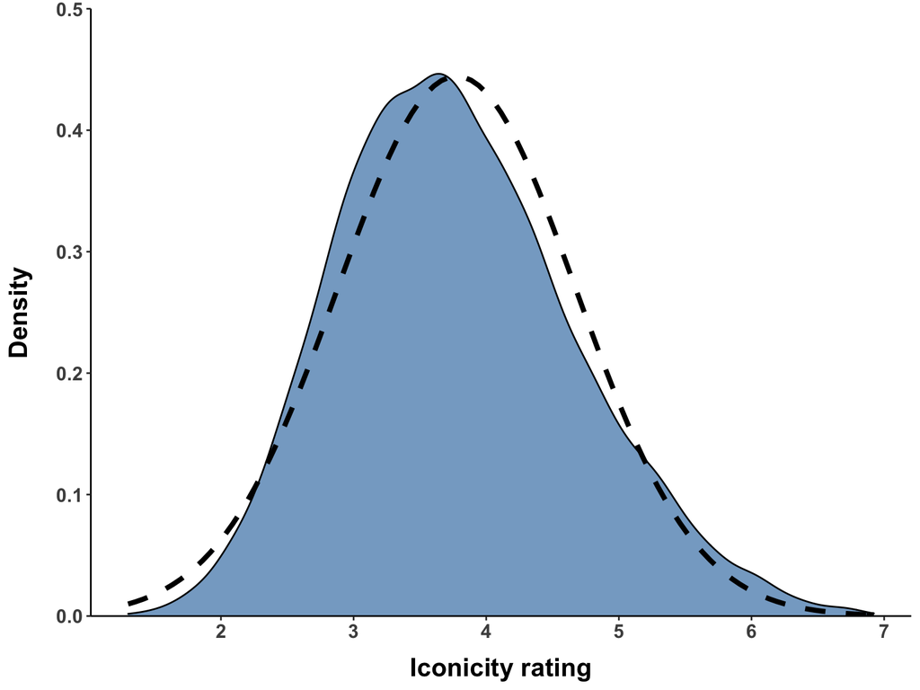

```r
# Main plot with mappings:

icon_p <- icon %>%
  ggplot(aes(x = rating))

# Add density geom and normal curve:

icon_p <- icon_p +
  geom_density(fill = 'steelblue', alpha = 0.7, col = 'black') +
  stat_function(fun = dnorm,
                args = list(mean = mean(icon$rating),
                            sd = sd(icon$rating)),
                col = 'black',
                linetype = 'dashed',
                size = 1.5)

# Add cosmetics:

icon_p <- icon_p +
  scale_y_continuous(expand = c(0, 0),
                     breaks = seq(0, 0.5, 0.1),
                     limits = c(0, 0.5)) +
  scale_x_continuous(breaks = 1:7) +
  xlab('Iconicity rating') +
  ylab('Density') +
  theme_classic() +

  # Axis labels:
  theme(axis.title.x = element_text(face = 'bold',
                                    size = 16,
                                    margin = margin(t = 10, b = 0,
                                                    l = 0, r = 0)),
        axis.title.y = element_text(face = 'bold',
                                    size = 16,
                                    margin = margin(r = 15, l = 0,
                                                    t = 0, b = 0))) +

  # Axis tick marks:
  theme(axis.text.x = element_text(face = 'bold',
                                   size = 12),
        axis.text.y = element_text(face = 'bold',
                                   size = 12))

# Show in markdown:

icon_p
```

```r
# Save:

ggsave(plot = icon_p,
       filename = '../figures/iconicity_ratings_density.pdf',
       width = 8, height = 6)
```

Make a plot out of this:

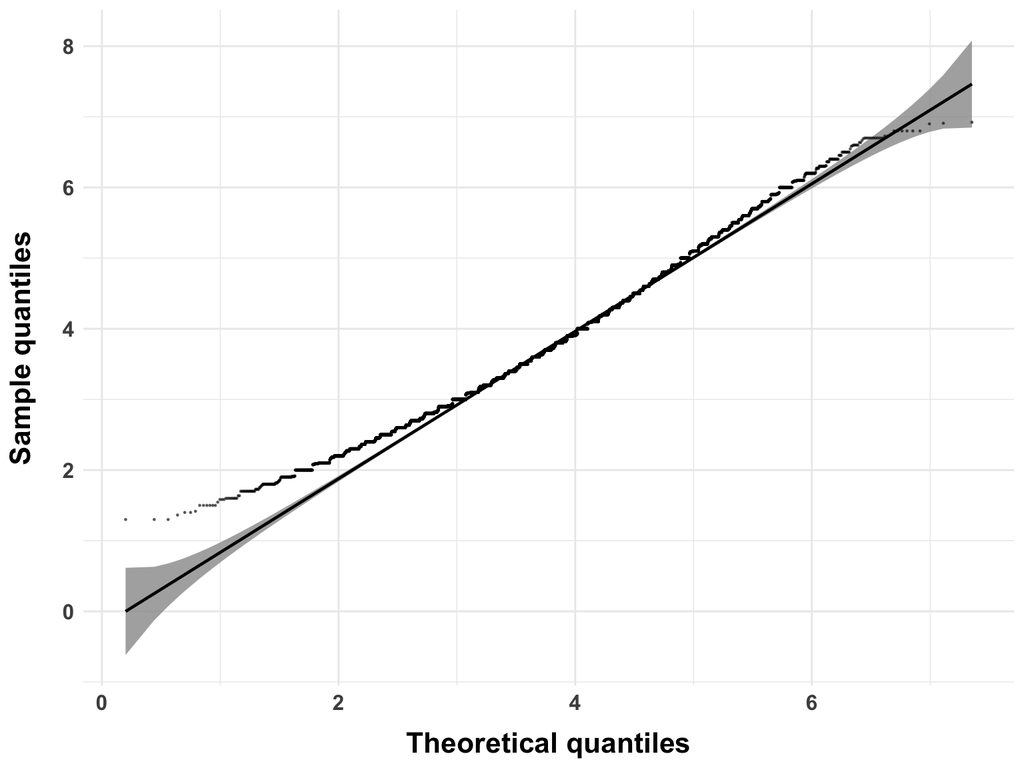

```r
# Main plot:

qq_p <- icon %>%
  ggplot(mapping = aes(sample = rating)) +
  stat_qq_band() +
  stat_qq_line() +
  stat_qq_point(alpha = 0.5, size = 0.2)

# Add cosmetics:

qq_p <- qq_p +
  xlab('Theoretical quantiles') +
  ylab('Sample quantiles') +
  theme_minimal() +

  # Axis labels:
  theme(axis.title.x = element_text(face = 'bold',
                                    size = 16,
                                    margin = margin(t = 10, b = 0,
                                                    l = 0, r = 0)),
        axis.title.y = element_text(face = 'bold',
                                    size = 16,
                                    margin = margin(r = 15, l = 0,
                                                    t = 0, b = 0))) +

  # Axis tick marks:
  theme(axis.text.x = element_text(face = 'bold',
                                   size = 12),
        axis.text.y = element_text(face = 'bold',
                                   size = 12))

# Show in markdown:

qq_p
```

```r
# Save:

ggsave(plot = qq_p,
       filename = '../figures/QQ_plot.pdf',
       width = 8, height = 6)
```

Create the Pollock (2018) style plot:

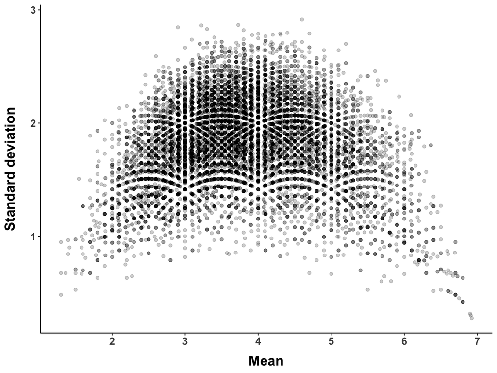

```r
# Main plot:

pollock_p <- icon %>%
  ggplot(aes(x = rating, y = rating_sd)) +
  geom_point(alpha = 0.2)

# Add cosmetics:

pollock_p <- pollock_p +
  xlab('Mean') +
  ylab('Standard deviation') +
  scale_x_continuous(breaks = 1:7) +
  theme_classic() +

  # Axis labels:
  theme(axis.title.x = element_text(face = 'bold',
                                    size = 16,
                                    margin = margin(t = 10, b = 0,
                                                    l = 0, r = 0)),
        axis.title.y = element_text(face = 'bold',
                                    size = 16,
                                    margin = margin(r = 15, l = 0,
                                                    t = 0, b = 0))) +

  # Axis tick marks:
  theme(axis.text.x = element_text(face = 'bold',
                                   size = 12),
        axis.text.y = element_text(face = 'bold',
                                   size = 12))

# Show in markdown:

pollock_p
```

```r
# Save:

ggsave(plot = pollock_p,
       filename = '../figures/pollock_2018.pdf',
       width = 8, height = 6)
```

Create a double plot of normal distribution with Pollock (2018) graph:

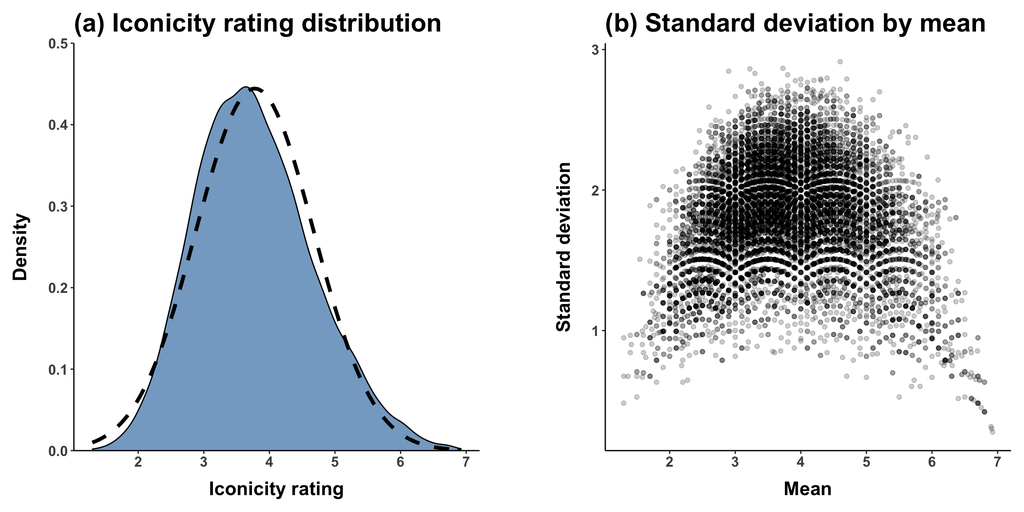

```r
# Add titles:

icon_p <- icon_p +
  ggtitle('(a) Iconicity rating distribution') +
  theme(title = element_text(face = 'bold',
                             size = 18,
                             margin = margin(t = 0, b = 15,
                                             r = 0, l = 0)))

pollock_p <- pollock_p +
  ggtitle('(b) Standard deviation by mean') +
  theme(title = element_text(face = 'bold',
                             size = 18,
                             margin = margin(t = 0, b = 15,
                                             r = 0, l = 0)))

# Put into plot together:

figure_1 <- icon_p + plot_spacer() + pollock_p +
  plot_layout(widths = c(8, 1, 8))


# Show in script:

figure_1
```

```r
# Save:

ggsave(plot = figure_1,
       filename = '../figures/figure1.pdf',
       width = 12, height = 5)
ggsave(plot = figure_1,
       filename = '../figures/figure1.png',
       width = 12, height = 5)
```

## Correlate with old ratings and imputed ratings

Merge this with Winter et al. (2017) iconicity ratings:

```r
icon <- left_join(icon, winter_2017)
```

Correlate this:

```r
with(icon, cor.test(rating, old_iconicity, use = 'complete.obs'))
```

```
##
##  Pearson's product-moment correlation
##
## data:  rating and old_iconicity
## t = 41.935, df = 2735, p-value < 2.2e-16
## alternative hypothesis: true correlation is not equal to 0
## 95 percent confidence interval:
##  0.6022241 0.6478578
## sample estimates:
##       cor
## 0.6255757
```

Merge this with the Dingemanse & Thompson (2020) data to correlate with imputed norms:

```r
icon <- left_join(icon, ding)
```

Check against imputed ratings from the Dingemanse & Thompson (2020) file:

```r
with(icon, cor.test(rating, ico_imputed, use = 'complete.obs'))
```

```
##
##  Pearson's product-moment correlation
##
## data:  rating and ico_imputed
## t = 65.912, df = 12849, p-value < 2.2e-16
## alternative hypothesis: true correlation is not equal to 0
## 95 percent confidence interval:
##  0.4896385 0.5154823
## sample estimates:
##       cor
## 0.5026727
```

```r
with(icon, cor.test(rating, ico_imputed_monomorph, use = 'complete.obs'))
```

```
##
##  Pearson's product-moment correlation
##
## data:  rating and ico_imputed_monomorph
## t = 45.329, df = 12849, p-value < 2.2e-16
## alternative hypothesis: true correlation is not equal to 0
## 95 percent confidence interval:
##  0.3562987 0.3861120
## sample estimates:
##      cor
## 0.371301
```

Reasonably high correlations given that this is imputed.

Merge this with the Perry et al. (2015) data:

```r
icon <- left_join(icon, perry_2015)
```

Check against the different ratings from Perry et al. (2015):

```r
with(icon, cor.test(rating, E1_written, use = 'complete.obs'))
```

```
##
##  Pearson's product-moment correlation
##
## data:  rating and E1_written
## t = 15.525, df = 560, p-value < 2.2e-16
## alternative hypothesis: true correlation is not equal to 0
## 95 percent confidence interval:
##  0.4879707 0.6038526
## sample estimates:
##       cor
## 0.5485404
```

```r
with(icon, cor.test(rating, E2_spoken, use = 'complete.obs'))
```

```
##
##  Pearson's product-moment correlation
##
## data:  rating and E2_spoken
## t = 13.064, df = 558, p-value < 2.2e-16
## alternative hypothesis: true correlation is not equal to 0
## 95 percent confidence interval:
##  0.4178619 0.5449653
## sample estimates:
##       cor
## 0.4839619
```

```r
with(icon, cor.test(rating, E3_guessing, use = 'complete.obs'))
```

```
##
##  Pearson's product-moment correlation
##
## data:  rating and E3_guessing
## t = 11.217, df = 559, p-value < 2.2e-16
## alternative hypothesis: true correlation is not equal to 0
## 95 percent confidence interval:
##  0.3585604 0.4938782
## sample estimates:
##       cor
## 0.4286199
```

This completes this analysis.